# Univariate exploratory data analysis

GEOG 30323

September 18, 2018

## Time for data!

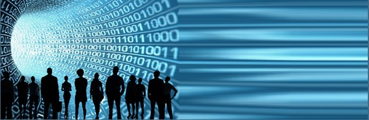

Source: [bigdatapix.tumblr.com](http://bigdatapix.tumblr.com/)

### Exploratory data analysis

- “Detective work” to summarize and explore datasets

Includes:

- Data acquisition and input
- Data cleaning and wrangling (“tidying”)
- Data transformation and summarization
- Data visualization

Your core Python tools for EDA: NumPy, pandas, and seaborn/matplotlib

### NumPy

- Extension to Python; the core Python package for numerical computing
- Standard import: `import numpy as np`
- Data structure: the NumPy **array**. Sort of like a list - but with more methods, and can be multidimensional

```python
import numpy as np

y = np.array([[2, 4, 6, 8, 10, 12],
             [1, 3, 5, 7, 9, 11],
             [10, 12, 14, 18, 22, 14],
             [9, 3, 3, 3, 3, 1]])
```

### Pandas

- Built on top of NumPy; adds support for table-like data structures in Python
- Standard import: `import pandas as pd`
- Sequences of data are stored as **Series** objects, which collectively form **DataFrames**

```python
import pandas as pd

df = pd.DataFrame(y, columns = ['x' + str(num) for num in range(1, 7)])
```

## The pandas DataFrame

- Commonly, DataFrames are created by reading in external data, like CSV files
- Download link: http://personal.tcu.edu/kylewalker/data/grad_rates.csv

```python
# To read in CSV files, we use the pd.read_csv function
grad = pd.read_csv("grad_rates.csv")
```

### The pandas DataFrame

- Each observation forms a **row**, defined by an **index**; attributes of those observations are found in the **columns** of the DataFrame

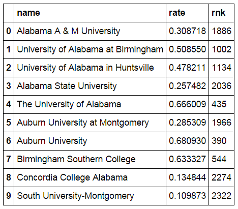

- Columns are accessible as indices, e.g. `grad['rate']`, or as attributes of the data frame, e.g. `grad.rate`

### Levels of measurement

- **Nominal**: qualitative, descriptive, categories
- **Ordinal**: ordering or ranking; however, no information about distance between ranks
- **Interval**: additive; no natural zero (zero is a meaningful value)
- **Ratio**: multiplicative; natural zero (zero means an absence of a value)

Make sure you know your column types (`dtypes`) and levels of measurement before doing analysis!

### Measures of central tendency

- **Mode**: the most typical value in a distribution
- **Median**: the “balancing point” in a distribution (50 percent of observations above and below)
- **Mean**: the arithmetic average of a distribution

The *mean* of a sample ($\overline{x}$) is calculated as follows:

$$\overline{x} = \dfrac{x_1 + x_2 + ... + x_n}{n}$$

where $n$ is the number of elements in the sample.

### Measures of dispersion

- **Range**: difference between maximum and minimum values in a distribution
- **Interquartile range**: difference between the values at the 25 percent and 75 percent points in a distribution
- **Variance** and **standard deviation**

## Variance

- A measure of the **spread** of a sample. The variance is computed as:

$${\sigma}^2 = \dfrac{\sum\limits_{i=1}^{n}(x_i - \overline{x})^2}{n}$$

or, in simpler terms, the average of the squared deviations of the values of a sample from its mean.

## Standard deviation

- Computed as the square root of the variance; denoted by $\sigma$.
- Offers a standardized way to discuss the spread of a distribution. For example, in a normally distributed sample:
  - About 67 percent of the values will be within one standard deviation of the mean
  - About 95 percent of the values will be within two standard deviations of the mean
  - About 99 percent of the values will be within three standard deviations of the mean

### Descriptive statistics in pandas

- Descriptive stats are available in `pandas` as data frame methods, e.g. `grad.mean()`, `grad.std()`
- Calling `.describe()` will give you back a number of important descriptive stats at once

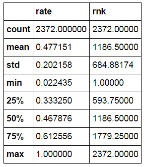

```python
grad.describe()
```

## Exploratory visualization

- Often, when exploring a dataset, you’ll want to use graphical representations of your data to help reveal insights/trends
- **Visualization**: Graphical representation of data

### Visualization in Python

- Core visualization package in Python: `matplotlib` - which comes pre-installed with Anaconda
- `seaborn`: extension to `matplotlib` to make your graphics look nicer! Standard import: `import seaborn as sns`.

## Histograms

- **Histogram**: graphical representation of a frequency distribution
- Observations are organized into **bins**, and plotted with values along the x-axis and the number of observations in each bin along the y-axis
- **Normal distribution**: histogram is approximately symmetrical (a “bell curve”)
- Histograms are built into `pandas`

### Example histogram

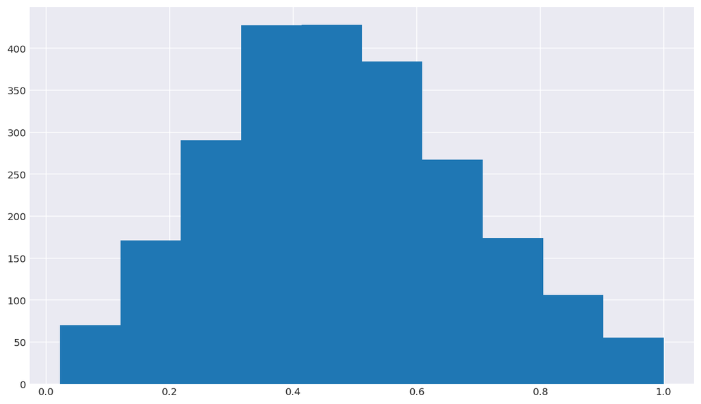

```python
import seaborn as sns
sns.set_style("darkgrid")

grad.rate.hist()
```

### Density plots

- Smooth representations of your data can be produced with **kernel density plots**
- Accessible from both `pandas` and `seaborn`

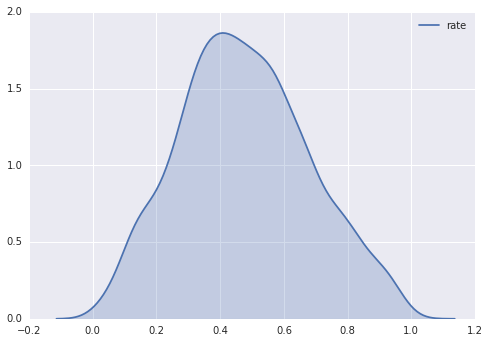

```python
sns.kdeplot(grad.rate, shade = True)
```

### Box plots

- Also termed “box and whisker plots” - alternative way to show distribution of values graphically

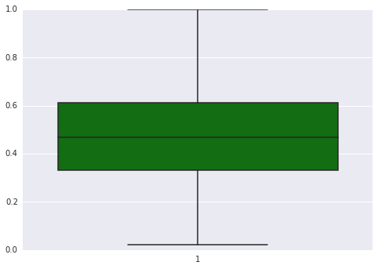

```python
sns.boxplot(grad.rate, color = "green", orient = "v")
```

### Anatomy of a box plot

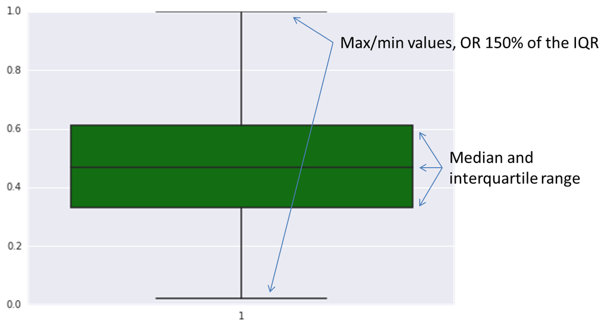

- Dots beyond the whiskers: **outliers**

### Violin plots

- Combinations of box plots and kernel density plots

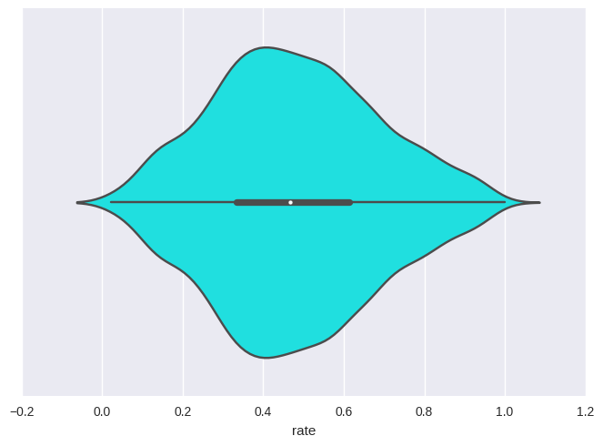

```python
sns.violinplot(grad['rate'], color = 'cyan')
```